# Practical machine learning project (Human Activity Recognition)

## DATA

- Training data https://d396qusza40orc.cloudfront.net/predmachlearn/pml-training.csv
- Test data https://d396qusza40orc.cloudfront.net/predmachlearn/pml-testing.csv
- Data source http://groupware.les.inf.puc-rio.br/har.

### Load data

```r
library(ggplot2); library(caret);
setwd("~/R/Cousera R/Machine learning")
har <- read.csv("pml-training.csv", header=TRUE, na.strings = c("NA",""," "))
#summary(har)
```

Many columns have NA’s = 19216. Remove columns occupied with NA over 90%. Remove columns which is irrelevant to human activity: “X”,“user_name”, “raw_timestamp_part_1”, “raw_timestamp_part_2”, “cvtd_timestamp”, “new_window”, “num_window”.

```r
NAnum <-apply(is.na(har),2,sum)
NAcol <- NAnum > nrow(har)*0.9
har <- har[,!NAcol]
har <- har[,8:60]
```

Genarate training and testing dataset

```r
inTrain <- createDataPartition(y = har$classe, p = 0.4, list = FALSE)
training <- har[inTrain,]
testing <- har[-inTrain,]
```

First I tried 4 models (Decision tree, Naive Bayes, Random forest, Gradient boosting model) to choose best classification model for this dataset.

```r
library(doSNOW)
cls<-makeCluster(6) # Number of cores you want to use
registerDoSNOW(cls) # Register the cores.

moddt <- train(classe ~ ., method= "rpart", data= training)               #Decision tree
modnb <- train(classe ~ ., data=training, method="nb")                    #Naive Bayes
modrf <- train(classe ~ ., data= training, method= "rf", prox= TRUE)      #Random forest
modgbm <- train(classe ~ ., method= "gbm",data= training, verbose=FALSE)  #Gradient boosting model

stopCluster(cls)  # Free up your cores again.
```

```r
cls<-makeCluster(6) # Number of cores you want to use
registerDoSNOW(cls) # Register the cores.

modrf5 <- train(classe ~ ., data = training, method = "rf", trControl = trainControl(method = "repeatedcv", number = 5, repeats = 3))
# Random forest with 5 fold cross validation
modrf10 <- train(classe ~ ., data = training, method = "rf", trControl = trainControl(method = "repeatedcv", number = 10, repeats = 3))
# Random forest with 10 fold cross validation
modrf20 <- train(classe ~ ., data = training, method = "rf", trControl = trainControl(method = "repeatedcv", number = 20, repeats = 3))
# Random forest with 20 fold cross validation

modrf5
```

```
## Random Forest
##
## 7850 samples
##   52 predictor
##    5 classes: 'A', 'B', 'C', 'D', 'E'
##
## No pre-processing
## Resampling: Cross-Validated (5 fold, repeated 3 times)
##
## Summary of sample sizes: 6279, 6279, 6282, 6280, 6280, 6281, ...
##
## Resampling results across tuning parameters:
##
##   mtry  Accuracy   Kappa      Accuracy SD  Kappa SD
##    2    0.9807642  0.9756613  0.004016523  0.005085428
##   27    0.9809769  0.9759339  0.003402659  0.004306270
##   52    0.9677706  0.9592228  0.005636019  0.007130782
##
## Accuracy was used to select the optimal model using  the largest value.
## The final value used for the model was mtry = 27.
```

```r
modrf10
```

```
## Random Forest
##
## 7850 samples
##   52 predictor
##    5 classes: 'A', 'B', 'C', 'D', 'E'
##
## No pre-processing
## Resampling: Cross-Validated (10 fold, repeated 3 times)
##
## Summary of sample sizes: 7065, 7064, 7066, 7065, 7065, 7066, ...
##
## Resampling results across tuning parameters:
##
##   mtry  Accuracy   Kappa      Accuracy SD  Kappa SD
##    2    0.9831866  0.9787256  0.006219725  0.007872786
##   27    0.9830162  0.9785135  0.005307041  0.006712471
##   52    0.9703199  0.9624521  0.007474699  0.009454401
##
## Accuracy was used to select the optimal model using  the largest value.
## The final value used for the model was mtry = 2.
```

```r
modrf20
```

```
## Random Forest
##
## 7850 samples
##   52 predictor
##    5 classes: 'A', 'B', 'C', 'D', 'E'
##
## No pre-processing
## Resampling: Cross-Validated (20 fold, repeated 3 times)
##
## Summary of sample sizes: 7459, 7460, 7457, 7456, 7458, 7459, ...
##
## Resampling results across tuning parameters:
##
##   mtry  Accuracy   Kappa      Accuracy SD  Kappa SD
##    2    0.9839973  0.9797513  0.006599060  0.008353112
##   27    0.9841637  0.9799657  0.006852524  0.008670057
##   52    0.9708733  0.9631519  0.007665947  0.009698893
##
## Accuracy was used to select the optimal model using  the largest value.
## The final value used for the model was mtry = 27.
```

20 fold cross-validation model(modrf20) was the highest accuracy in training dataset. Higher number of corss validation reduced the error. Then I tested these models using tesing dataset(part of training dataset).

### Check random forest model – best

```r
predrf5 <- predict(modrf5,testing)
table(predrf5,testing$classe)
```

```
##
## predrf5    A    B    C    D    E
##       A 3335   26    0    0    0
##       B    9 2237   15    6    1
##       C    1   15 2026   34    6
##       D    2    0   12 1889   17
##       E    1    0    0    0 2140
```

```r
predrf10 <- predict(modrf10,testing)
table(predrf10,testing$classe)
```

```
##
## predrf10    A    B    C    D    E
##        A 3336   17    0    0    0
##        B    6 2252   22    0    0
##        C    1    9 2029   54   10
##        D    5    0    2 1875   13
##        E    0    0    0    0 2141
```

```r
predrf20 <- predict(modrf20,testing)
table(predrf20,testing$classe)
```

```
##
## predrf20    A    B    C    D    E
##        A 3335   25    0    0    0
##        B    9 2237   18    6    1
##        C    1   16 2024   32    6
##        D    2    0   11 1891   15
##        E    1    0    0    0 2142
```

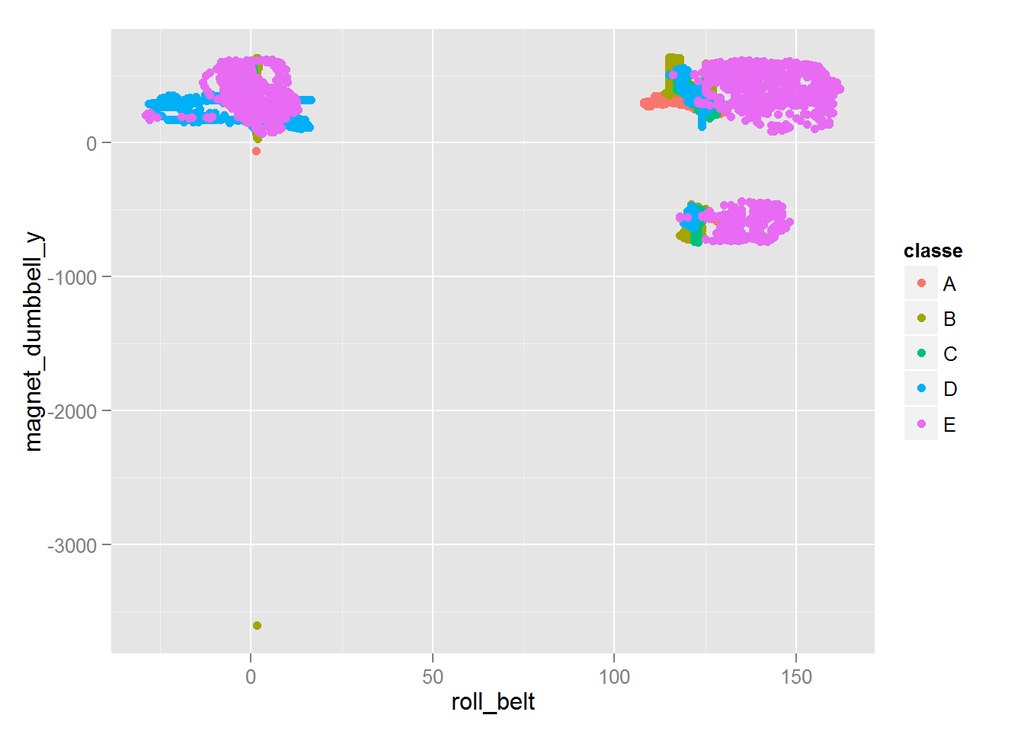

```r
testing$predrf20Right <- predrf20==testing$classe
qplot(roll_belt, magnet_dumbbell_y, colour=classe, data=testing)
```

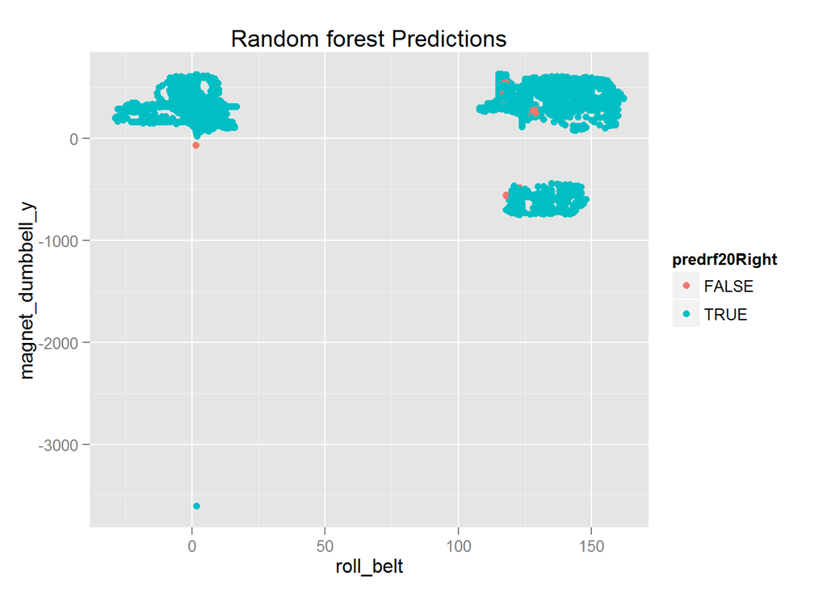

```r
qplot(roll_belt, magnet_dumbbell_y,colour=predrf20Right,data=testing,main="Random forest Predictions")
```

### Check other models

Other models are also visually inspected. To estimate the out of sample error the plots of prediction results were generated.

Check decision tree model – worst

```r
#library(rattle)
#library(rpart.plot)
#fancyRpartPlot(moddt$finalModel)
preddt <- predict(moddt,testing); testing$preddtRight <- preddt==testing$classe
table(preddt,testing$classe)
```

```
##
## preddt    A    B    C    D    E
##      A 3025  942  945  865  312
##      B   56  757   65  338  289
##      C  258  579 1043  726  602
##      D    0    0    0    0    0
##      E    9    0    0    0  961
```

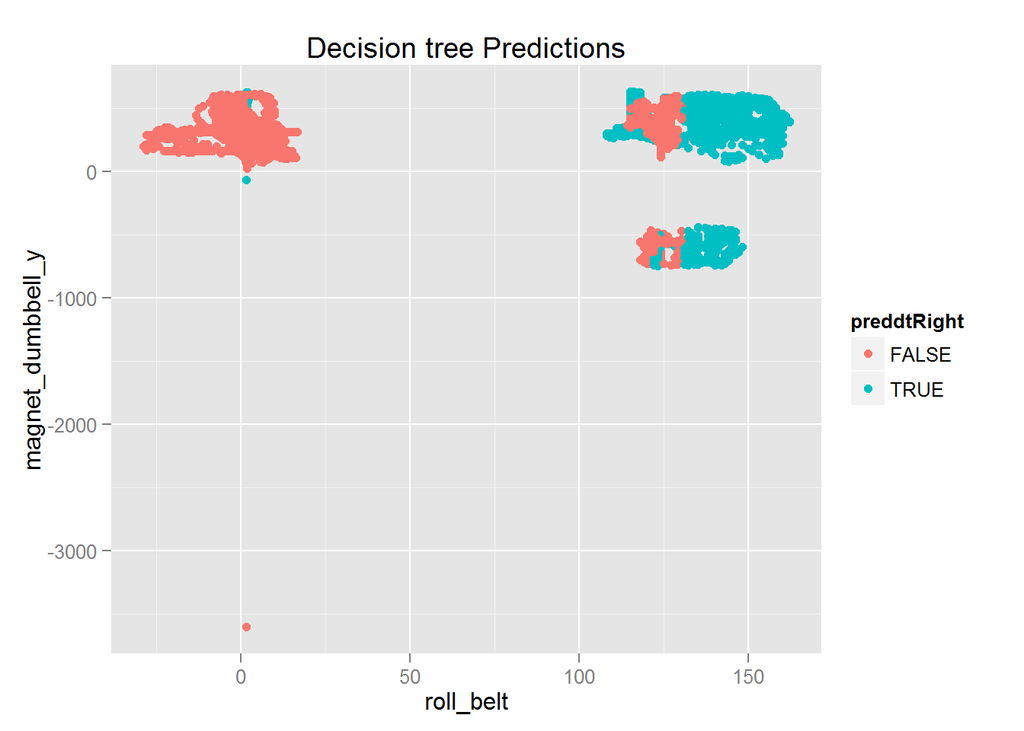

```r
qplot(roll_belt, magnet_dumbbell_y,colour=preddtRight,data=testing,main="Decision tree Predictions")
```

Check gradient boosting model – work

```r
predgbm <- predict(modgbm,testing); testing$predgbmRight <- predgbm==testing$classe
table(predgbm,testing$classe)
```

```
##
## predgbm    A    B    C    D    E
##       A 3278   77    0    1    7
##       B   43 2141   60    9   24
##       C    7   54 1964   62   16
##       D   18    5   24 1838   32
##       E    2    1    5   19 2085
```

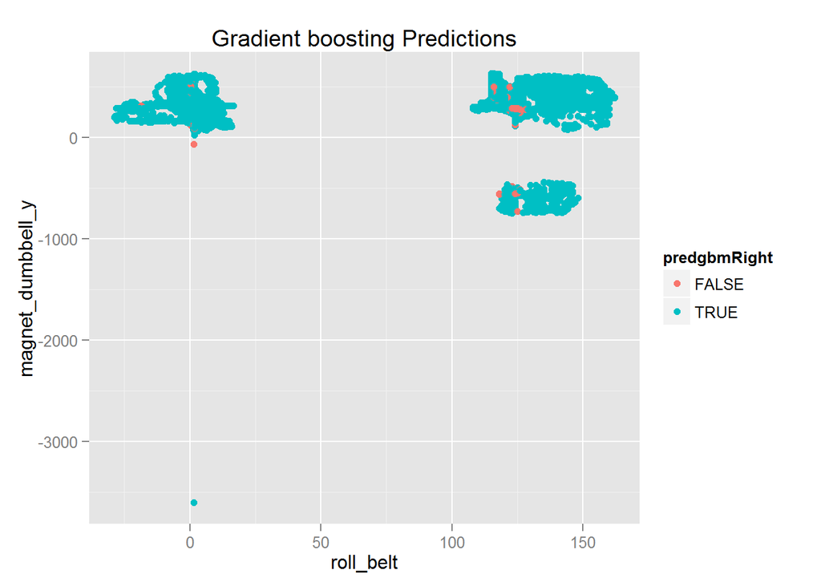

```r
qplot(roll_belt, magnet_dumbbell_y,colour=predgbmRight,data=testing,main="Gradient boosting Predictions")
```

Check Naive Bayes model – work

```r
prednb <- predict(modnb,testing); testing$prednbRight <- prednb==testing$classe
table(prednb,testing$classe)
```

```
##
## prednb    A    B    C    D    E
##      A 2361  185  138  129   74
##      B  139 1577  144    6  282
##      C  439  327 1735  361  102
##      D  405  173   35 1347   96
##      E    4   16    1   86 1610
```

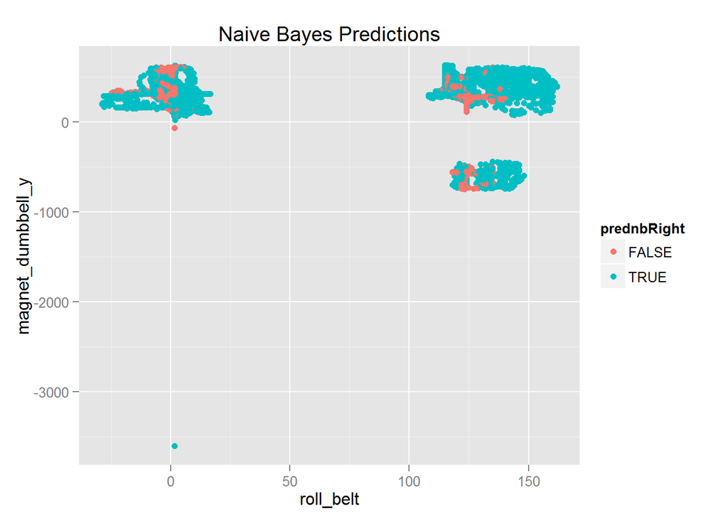

```r
qplot(roll_belt, magnet_dumbbell_y,colour=prednbRight,data=testing,main="Naive Bayes Predictions")
```

```r
stopCluster(cls)
```